# Lab2_Rivlin_Neria & Blonder_Yoav

yoav blonder

11 6 2021

## *Lab 2: Visualization Through `ggplot`*

**Contents**:

- Q0. Submission Instructions
- Q1. Basic Statistics (30 pt)
- Q2. Scouting Report (30 pt)
- Q3. Model Building (30 pt)
- Q4. Fix Problematic Plots (10 pt)

### Q0.Submission Instructions

This lab will be submitted in pairs using GitHub (if you don’t have a pair, please contact us).  
Please follow the steps in the [GitHub-Classroom Lab 2](https://classroom.github.com/g/6_Wy5z44) to create your group’s Lab 2 repository.  
**Important: your team’s name must be `FamilyName1_Name1_and_FamilyName2_Name2`**.  
You can collaborate with your partner using the git environment; You can either make commits straight to master, or create individual branches (recommended). However, once done, be sure to merge your branches to master - you will be graded using the most recent *master* version - your last push and merge before the deadline.  
**Please do not open/review other peoples’ repositories - we will be notified by GitHub if you do.**

Your final push should include this Rmd file (with your answers) together with the html file that is outputted automatically by knitr when you knit the Rmd. Anything else will be disregarded. In addition, please adhere to the following file format:  
`Lab_2_FamilyName1_Name1_and_FamilyName2_Name2.Rmd/html`

Some questions may require data wrangling and manipulation which you need to decide on.  
In some graphs you may need to change the graph limits. If you do so, please include the outlier points you have removed in a separate table.

Show numbers in plots/tables using standard digits and not scientific display. That is: 90000000 and not 9e+06.  
Round numbers to at most 3 digits after the dot - that is, 9.456 and not 9.45581451044

The required libraries are listed below the instructions. You are allowed to add additional libraries if you want. If you do so, *please explain what libraries you’ve added, and what is each new library used for*.

#### Background:

You’ve been hired as a data analyst at at football (soccer) club. Since this is a small and under-funded club, you will not have access to real-football data, but to data from the football computer game fifa18. Your job is to analyze this dataset and extract meaningful insights from the data in order to help your club make better decisions.

#### Data File:

You will load and analyze the fifa18 football dataset file called “fifa_data.csv”.  
The dataset contains detailed information about each player in the game, including: names, age, nationality, overall ability, estimated potential ability, current club and league, market value, salary (wage), ability at different football skills (also called ‘attributes’, e.g. Ball.control, Sprint.speed …), ability to play at different position in the game (CF, CM, …) and the preferred positions of the player.

Required Libraries:

```r
library(ggplot2)
library(dplyr)
library(corrplot)
library(scales)   # needed for formatting y-axis labels to non-scientific type
library(radarchart)
library(tidyr)
library(tidyverse)
library(reshape2) # melt
library(ggthemes)
library(rworldmap) # world map
library(modelr)
library(radarchart) #Spider chart
############################################
library(e1071) #Q1.c -  skewness() and kurtosis()
library(grid) # geom_segment
library(ggrepel)# Use ggrepel::geom_label_repel


options("scipen"=100, "digits"=4)  # avoid scientific display of digits. Take 4 digits.
```

## Q1. Basic Univariate Statistics (30 pt)

First, you are requested to load the fifa18 dataset and find and display general information about the players.

1. Make a plot showing the `overall` ability distribution of all players. How skewed is the distributions? does it have fat tails?  
   Plot on top of the `overall` distribution a Normal distribution matching its first two moments. Is the distribution described well by a Normal distribution? explain.
2. Make a plot comparing the multiple `overall` ability *distributions* of players according to the `continent` of the players. Describe which continents have especially good/bad players.
3. Make a plot showing the density of players’ `value` distribution.  
   Next, make a separate plot showing the density distribution of the *log* of players’ `value`.  
   Which of the two visualizations is better? explain.
4. Are the top-10 players with the highest `value` also the top-10 best players in terms of `overall` ability? Show tables for both and compare.  
   Who is the best player not in the top-10 valued players?
5. Show a table of the *10* *youngest* and *10* *oldest* teams in terms of *average* players `age`.

Loading the data:

```r
fifa_players <- data.frame(read.csv(url("https://raw.githubusercontent.com/DataScienceHU/DataAnalysisR_2021/master/data/fifa_data.csv")))
# Pre-processing:
for (i in c(3,6,7,10:71)) {
  fifa_players[,i]<-as.numeric((fifa_players[,i]))
}
fifa<-na.omit(fifa_players)
fifa_players <- fifa
fifa_players_info <- fifa[,c(1:11)] # players general info
fifa_players_attribures <- fifa[,c(1,12:45, 6)] # players different skills. Add overall
fifa_players_positions <- fifa[,c(1,46:72,6,7)] # players ability at different positions . Add overall
fifa_players_indicators <- fifa[,c(1,6,7,10,11)] # players general ability
```

Q1A

In order to see the overall distribution we are using a barplot. In order to check whether it is skewed we will use the skewness function we saw in class which returns a number. If the number is positive and far from 0 the distribution has a fat tail on the right, if its positive but close to 0 it has a small tail on the right. If its the same with a negative number its the same but with a left tail.

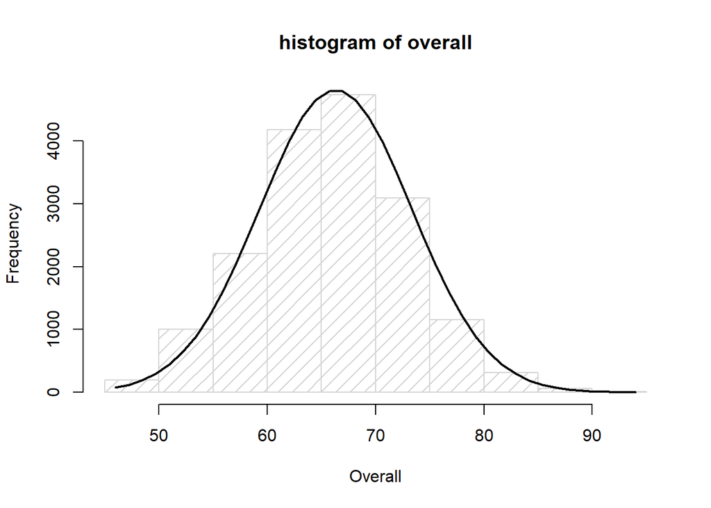

```r
ave_ove = mean(fifa$Overall)
med_ove = median(fifa$Overall)
sd_ove = sd(fifa$Overall)

h <- hist(fifa$Overall, breaks = 10, density = 10,
          col = "lightgray", xlab = "Overall", main = "histogram of overall")
xfit <- seq(min(fifa$Overall), max(fifa$Overall), length = 40)
yfit <- dnorm(xfit, mean = mean(fifa$Overall), sd = sd(fifa$Overall))
yfit <- yfit * diff(h$mids[1:2]) * length(fifa$Overall)
lines(xfit, yfit, col = "black", lwd = 2)
```

```r
skewness(fifa$Overall)
```

```
## [1] 0.008293
```

As we can see the distribution looks very normal. Next, the skewness number is small and positive so so there is a small tail to the right. After ploting a Normal distribution matching on top of the data we can see it almost fitts perfectly so the distribution is well described by a Normal distribution.

Q1B

Because we are asked to compare among 6 continents it is best to show the results with a multiple box plot. That way one can compare the median and see the residuals better.

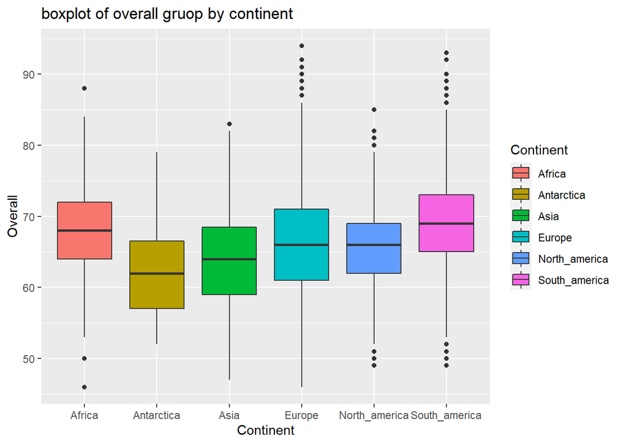

```r
fifa %>% ggplot(aes(x=Continent, y=Overall, fill=Continent)) +
  geom_boxplot()+labs(title = "boxplot of overall gruop by continent")
```

As we can see Africa and South America has the highest mean and the Quantile boxes are the highest among all continents so we can say they have the best players. But Europe and South America have many outliers on top with means extrimelly good players, so if we combine the outliers and the quantiles we can safely say South America has the best players.

Q1C

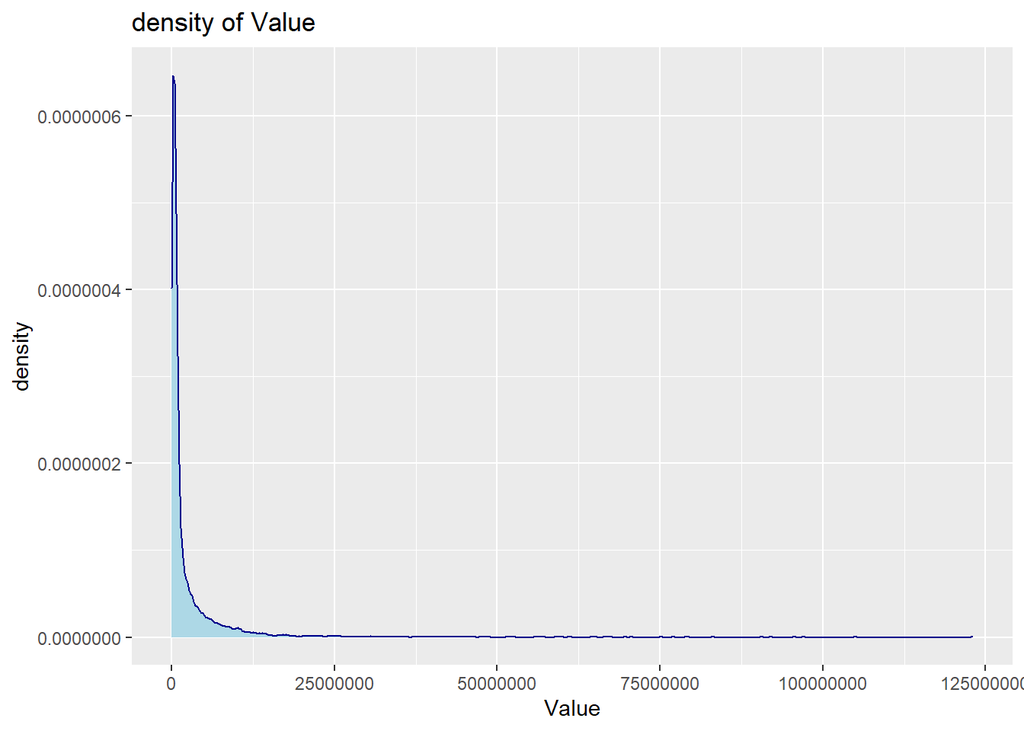

```r
ggplot(fifa, aes(x=Value))+
  geom_density(color="darkblue", fill="lightblue")+labs(title = "density of Value")
```

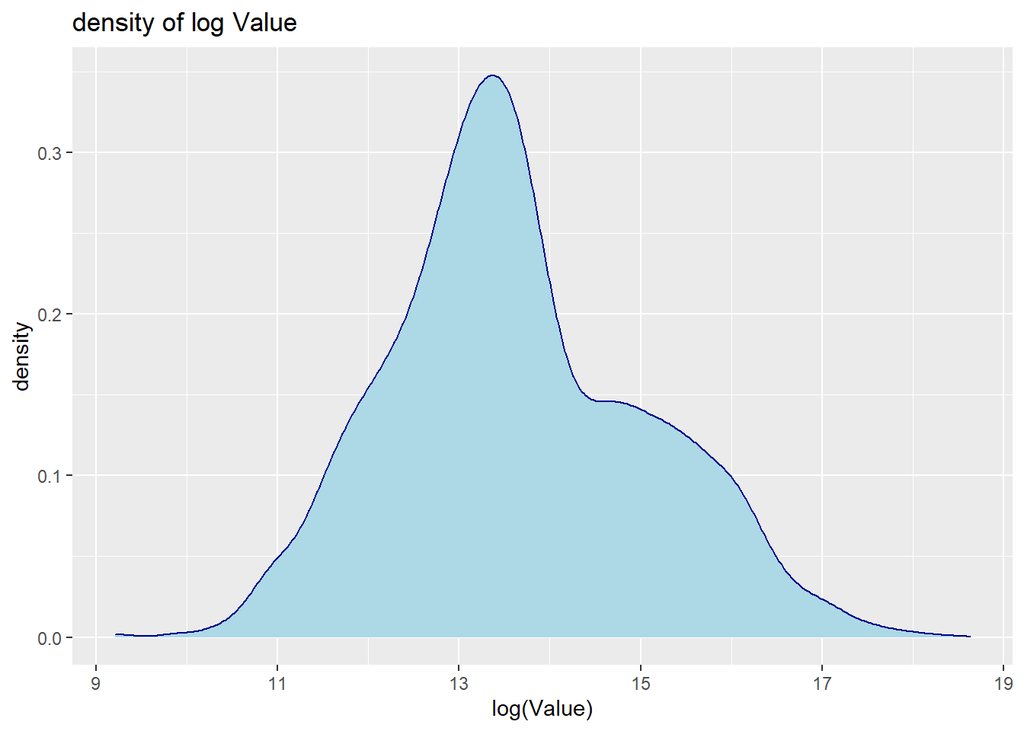

```r
ggplot(fifa, aes(x=log(Value)))+
  geom_density(color="darkblue", fill="lightblue")+labs(title = "density of log Value")
```

As we can see in the original density plot the numbers are very large so its very unreadable. On the other hand the log density is much clearer to the reader.

Q1D

In order to show the wanted tables we will use the head(n) function we saw in the past.

```r
q_1_D_f <- select(fifa,Name,Overall,Value)
q_1_D_1 <- q_1_D_f %>%
  arrange(desc(Overall)) %>%
  head(10)
q_1_D_1$Value = comma(q_1_D_1$Value)
print(q_1_D_1)
```

```
##                 Name Overall       Value
## 1  Cristiano Ronaldo      94  95,500,000
## 2           L. Messi      93 105,000,000
## 3             Neymar      92 123,000,000
## 4           M. Neuer      92  61,000,000
## 5         L. Su\303¡rez      92  97,000,000
## 6     R. Lewandowski      91  92,000,000
## 7          E. Hazard      90  90,500,000
## 8             De Gea      90  64,500,000
## 9        G. Higua\303n      90  77,000,000
## 10          T. Kroos      90  79,000,000
```

```r
q_1_D_2 <- q_1_D_f %>%
  arrange(desc(Value)) %>%
  head(10)
q_1_D_2$Value = comma(q_1_D_2$Value)
print(q_1_D_2)
```

```
##                 Name Overall       Value
## 1             Neymar      92 123,000,000
## 2           L. Messi      93 105,000,000
## 3         L. Su\303¡rez      92  97,000,000
## 4  Cristiano Ronaldo      94  95,500,000
## 5     R. Lewandowski      91  92,000,000
## 6          E. Hazard      90  90,500,000
## 7       K. De Bruyne      89  83,000,000
## 8          P. Dybala      88  79,000,000
## 9           T. Kroos      90  79,000,000
## 10       G. Higua\303n      90  77,000,000
```

Manuel Neuer is the best player not in the top 10 values player.

Q1E

```r
group_1E <- group_by(fifa,Club)
summ_1E <- summarize(group_1E, ave_age=mean(Age))
q_1_E_1 <- summ_1E %>%
  arrange(desc(ave_age)) %>%
  head(10)
print(q_1_E_1)
```

```
## # A tibble: 10 x 2
##    Club                              ave_age
##    <chr>                               <dbl>
##  1 Brisbane Roar                        31
##  2 Newcastle Jets                       31
##  3 FC Seoul                             30.8
##  4 Western Sydney Wanderers             30.8
##  5 Associaֳ§ֳ£o Chapecoense de Futebol    30.6
##  6 Adelaide United                      30.4
##  7 Jeonbuk Hyundai Motors               30.3
##  8 Clube Atlֳ©tico Paranaense           30
##  9 Grֳ×mio Foot-Ball Porto Alegrense     30
## 10 Sydney FC                            30
```

```r
q_1_E_2 <- summ_1E %>%
  arrange(desc(-ave_age)) %>%
  head(10)
print(q_1_E_2)
```

```
## # A tibble: 10 x 2
##    Club              ave_age
##    <chr>               <dbl>
##  1 Sevilla Atlֳ©tico    19.8
##  2 FC Barcelona B       20.4
##  3 Werder Bremen II     21.5
##  4 LOSC Lille           21.6
##  5 PSV                  21.9
##  6 Crewe Alexandra      21.9
##  7 FC Nordsjֳ¦lland      22
##  8 Ajax                 22.1
##  9 KRC Genk             22.1
## 10 Barnsley             22.1
```

As one can see we only grouped by the clubs and summarized by age for the old players ans by -age for young players.

## Q2. Scouting Report (30 pt)

You are in charge of the scouting division. The goal of this division is to follow players’ `potential` and `overall` ability, and identify undervalued players - that is, players whose current value is lower compared to what would be expected based on their predicted future ability.

1. Plot the *average* `potential` ability by `age` of all players, for players 35 years old or younger
2. Plot the *average difference* between a player’s `overall` ability to `potential` ability as a function of `age`, up to age 35. At what ages should we expect to find players for future development based on this graph?
3. We are seeking young ($age \leq 21$) players with high `potential` ($>70$). Show a scatter plot of these players comparing their `potential` ability (x-axis) and current `value` (y-axis).  
   Find the 10 most-undervalued players, i.e. having the lowest `value` compared to their predicted value by `potential` using a simple linear regression model.  
   Calculate for each of them what is a fair `value` matching their `potential` that you be willing to pay in order to by them to your club and show these 10 players with their name, `age`, `overall` ability, `potential`, actual `value` and fair `value` it a table.
4. Your boss wants to fly abroad to recruit promising players. Use the `rworldmap` package to display the world map and color each country based on the *median* `potential` of players from this nationality.
5. Repeat the above analysis but this time display a world map where each country is colored by the *median ratio* of `potential` to `value` of players. Find an under-valued country you’d recommend to travel to (i.e. a country with cheap players compared to their `potential` average quality).

Q2A

In order to answer the question first we filter the players by age. Then we group them by the age and summarize that group by the potential mean.

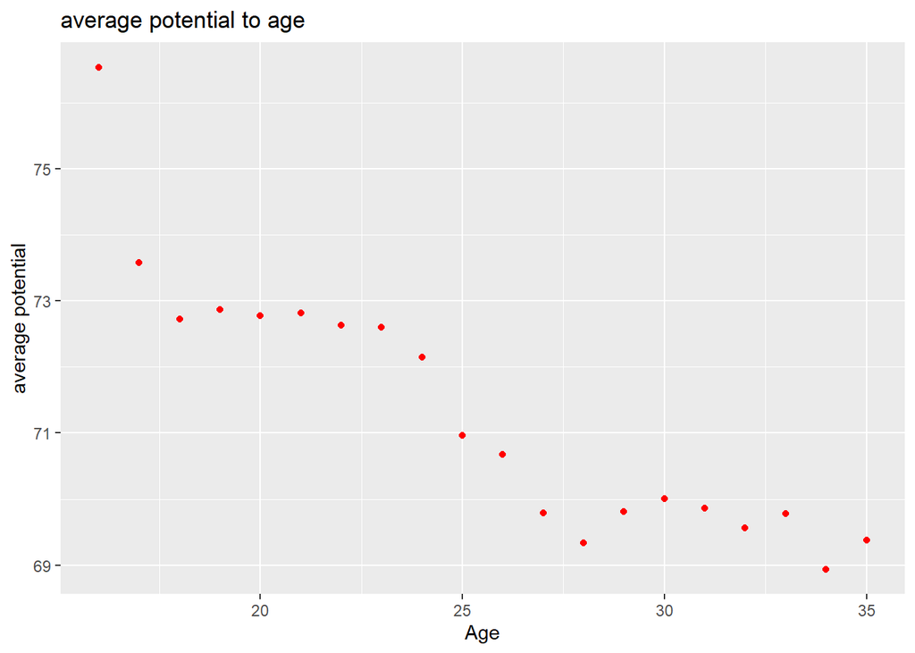

```r
filter_2A <- filter(fifa,Age <= 35)
group_2A <- group_by(filter_2A,Age)
summ_2B <- summarize(group_2A, ave_pot=mean(Potential))

ggplot(summ_2B, aes(x = Age, y = ave_pot))+geom_point(data = summ_2B, color = "red") + labs(x="Age", y="average potential",title = "average potential to age")
```

In the plot we can see that younger players have a higher potential average, and as they get older there average gets lower.

Q2B

We are asked to do the same as before but for the difference between the overall and the potential.

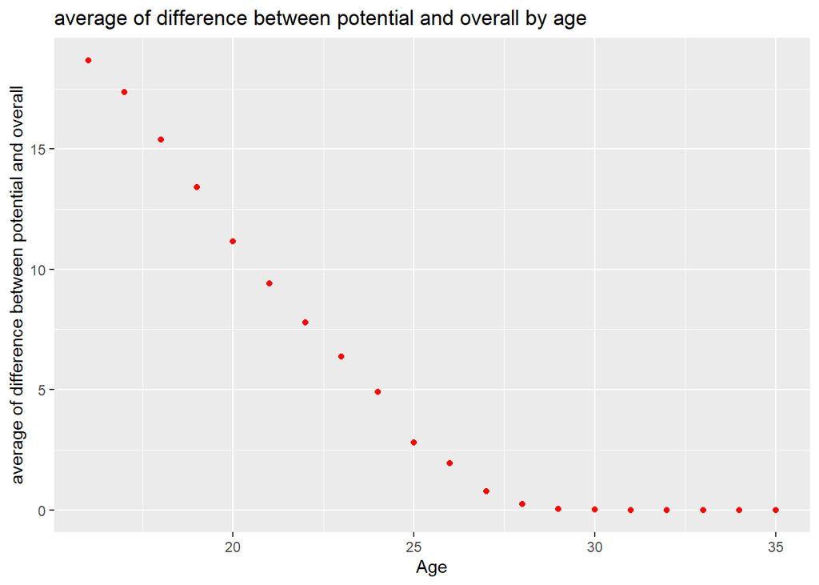

```r
filter_2B <- filter(fifa,Age <= 35)
group_2B <- group_by(filter_2B,Age)
summ_2B <- summarize(group_2B, ave_def_pot_over=-mean(Overall - Potential))

ggplot(summ_2B, aes(x = Age, y = ave_def_pot_over))+geom_point(data = summ_2B, color = "red") + labs(x="Age", y="average of difference between potential and overall",title = "average of difference between potential and overall by age")
```

As we can see as from age 27 the difference between the potential and the overall tends to zero, and before that age the playersstill have a potential. The players with most potential are the youngest.

Q2C

```r
filter_2C <- filter(fifa,Age < 21 & Potential > 70)
new_table2c <- select(filter_2C,Name,Age,Overall,Potential,Value)
reg_2C <- lm(data=new_table2c,Value ~ Potential)
sum_red_2C <- summary(reg_2C)
intercept <- sum_red_2C$coefficients[1]
slope <- sum_red_2C$coefficients[2]
resid <- resid(reg_2C) #List of residuals
new_table2c$real_value <- resid
new_table2c1 <- new_table2c %>%
  arrange(desc(-real_value)) %>%
  head(10)
new_table2c2 <- new_table2c %>%
  arrange(desc(real_value))
new_table2c1$real_value <- ((new_table2c1$Potential)*(slope)+intercept)
new_table2c1
```

```
##              Name Age Overall Potential   Value real_value
## 1        A. Gomes  16      64        90  975000    6889563
## 2    W. Far\303\303±ez  19      73        87       0    5649739
## 3      M. Edwards  18      65        87 1200000    5649739
## 4       J. Sancho  17      63        86  800000    5236464
## 5     C. Fr\303¼chtl  17      65        86  975000    5236464
## 6  E. Abouchabaka  17      62        85  650000    4823189
## 7        V. Thill  17      63        85  800000    4823189
## 8          J. Arp  17      63        85  825000    4823189
## 9    R. Sessegnon  17      67        86 1300000    5236464
## 10      R. Harper  17      61        84  550000    4409915
```

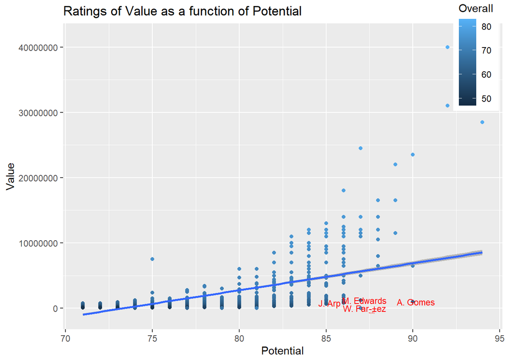

```r
p2C <- ggplot(data = new_table2c2, aes(x = Potential, y = Value))+ geom_text(aes(label=Name), size = 2.5, hjust='bottom',check_overlap = TRUE, nudge_x = 0.05)+ geom_smooth(method="lm", se=TRUE, fullrange=FALSE, level=0.95) +  theme_gray() + theme(legend.position = c(0.94, 0.9)) + ggtitle('Ratings of Value as a function of Potential - players names') + geom_text(data =new_table2c1, aes(label=Name), size = 3, nudge_x = 0.05,col="red")
p2C1 <- ggplot(data = new_table2c2, aes(x = Potential, y = Value))+ geom_point(aes(color=Overall))+ geom_smooth(method="lm", se=TRUE, fullrange=FALSE, level=0.95) +   geom_smooth(method="lm", se=TRUE, fullrange=FALSE, level=0.95) +  theme_gray() + theme(legend.position = c(0.94, 0.9)) + ggtitle('Ratings of Value as a function of Potential') + geom_text(data =new_table2c1, aes(label=Name), size = 3,check_overlap = TRUE, nudge_x = 0.2,col="red")
p2C1
```

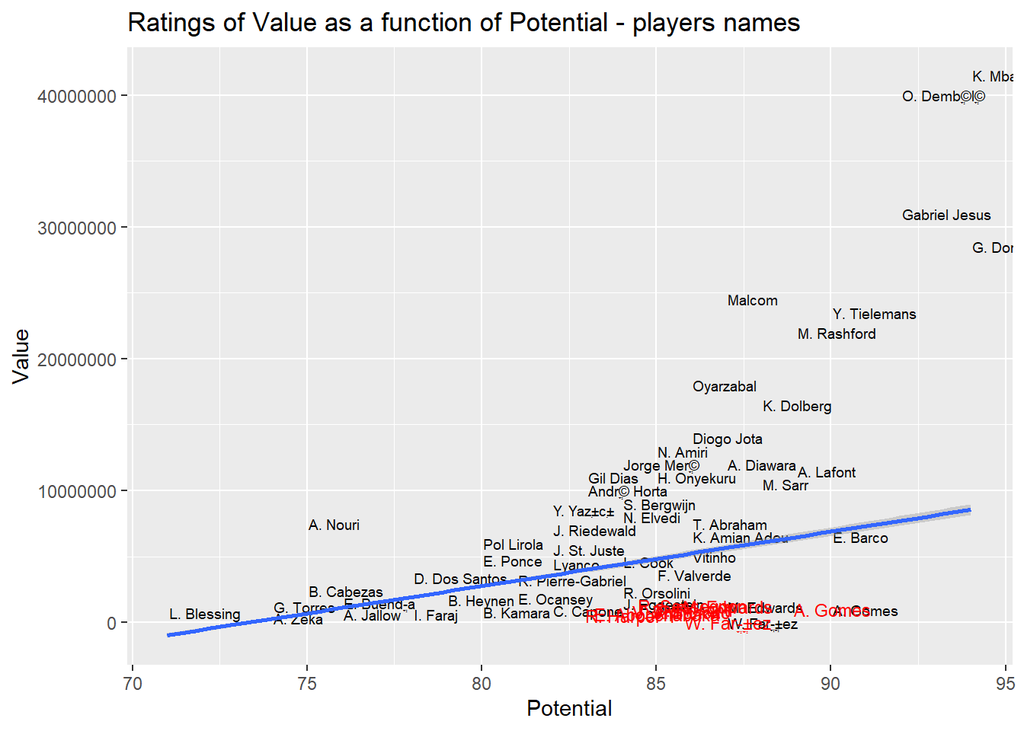

```r
p2C
```

As we can see we got a new table of the top 10 players that are underrated. In the regression we want the players that are far from the abline down and right, meaning with low price and high value. We even colored in red those players.

Q2D

```r
group_2D <- group_by(fifa,Nationality)
summ_2D <- summarize(group_2D, med_pot=median(Potential))
sPDF <- joinCountryData2Map( summ_2D, joinCode = "NAME"
                              , nameJoinColumn = "Nationality")
```

```
## 133 codes from your data successfully matched countries in the map
## 4 codes from your data failed to match with a country code in the map
## 110 codes from the map weren't represented in your data
```

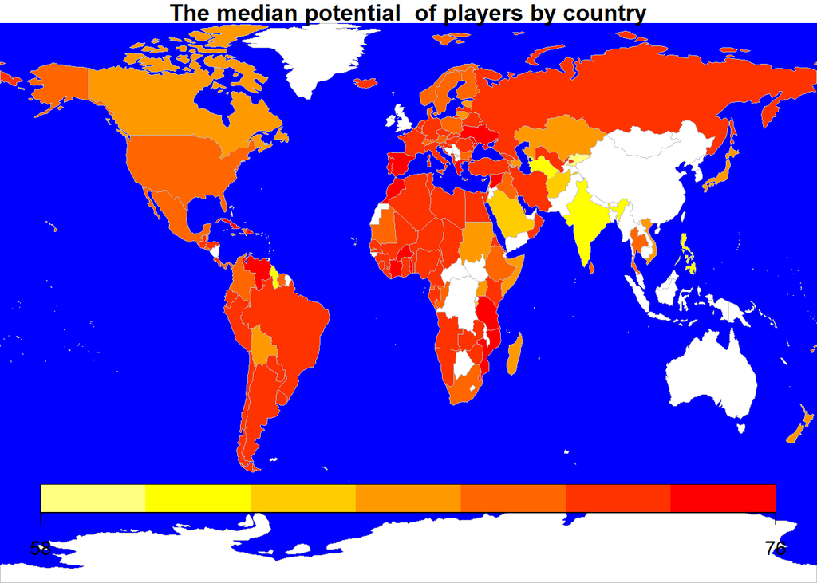

```r
par(mai=c(0,0,0.2,0),xaxs="i",yaxs="i")
mapCountryData( sPDF, nameColumnToPlot="med_pot",,catMethod = "fixedWidth",
               oceanCol = "blue", missingCountryCol = "white",
               mapTitle = "The median potential  of players by country",
               aspect = "variable")
```

White countries are not in the table, the more the color is dark the bigger chance to find a great player, for the average there is high. (as we can see South America is pretty dark as we showed in a previous question).

Q2E

```r
group_2E <- group_by(fifa,Nationality)
summ_2E <- summarize(group_2E, med_pot_val=(median(Value)/median(Potential)))
#summ_2E$med_pot_val = round(summ_2E$med_pot_val,5)
filter_2E <- filter(summ_2E,med_pot_val != Inf)
sPDF_2E <- joinCountryData2Map( filter_2E, joinCode = "NAME"
                              , nameJoinColumn = "Nationality")
```

```
## 133 codes from your data successfully matched countries in the map
## 4 codes from your data failed to match with a country code in the map
## 110 codes from the map weren't represented in your data
```

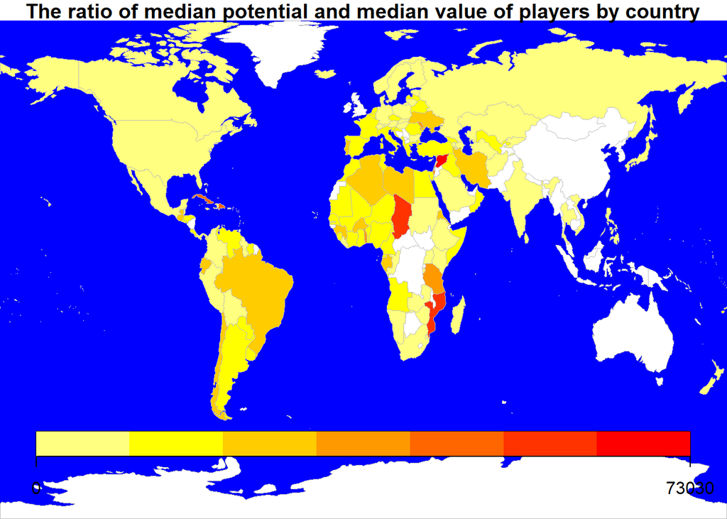

```r
par(mai=c(0,0,0.2,0),xaxs="i",yaxs="i")
mapCountryData( sPDF_2E, nameColumnToPlot="med_pot_val",,catMethod = "fixedWidth",
               oceanCol = "blue", missingCountryCol = "white",
               mapTitle = "The ratio of median potential and median value of players by country",
               aspect = "variable")
```

## Q3. Correlations Analysis (30 pt)

In this question we find and display different skills and their correlations

1. We are interested in finding out which positions are similar in terms of players’ performance.  
   Extract the 26 non-goalkeeper positions (`CAM, CB, ..., ST`). Calculate the correlation between players’ ability in each pair of positions and show a heatmap correlation-plot of the correlations’ matrix. What three positions have the *least* average correlations with other skills?  
   We are interested in finding out which skills are similar in terms of players’ performance at the position. Extract the 29 skills for non-goalkeeper players (Acceleration, …, Volleys, except ’GK.*’ skills). Calculate the correlation between players’ ability in each pair of skills and show a heatmap correlation-plot of the correlations’ matrix. What two skills seem least correlated with other skills?
2. Consider the following indicators of players performance: `overall` players’ performance, their `potential`, their salary (`wage`) and their market `value`. Show a correlation-plot of players’ *34* skill levels (`Acceleration`, …, `Volleys`) vs. these four indicators. Find the *10* skills with the highest *average* correlation with the four inidcators and list them in a table.
3. Build a team of *11 different* players with the following rules:
- For each of the *26* non-goalkeaper positions (*26* from above plus goalkeaper, `GK`), find the player with the best performance at this position.
- Find the goal keaper (`Preffered.Positions` is `GK`) with the best `overall` performance.
- From the players obtained above, find *11 distinct* players maximizing the average `overall` performance of the team, with the constraint that there must be a goalkeaper (preferred position `GK`).
- List the players in a table including their `overall` performance and the team average `overall` score.  
  Next, peak six *different* players of your choice from your team, one of which is the goalkeaper. Using the function `radarchart::chartJSRadar`, graph their abilities (individually for all 6 players) in the top *10* skills according to 3.b in a [radar chart](https://en.wikipedia.org/wiki/Radar_chart) (also called ‘spider chart’) graph. See below an example for such a chart.
4. We are interested in determining how the player’s abilities in different positions changes with age. Repeat the analysis of question 2.a., but this time show the *34* different skills  
   Which skills peak at youngest/oldest ages?
5. Your boss suggests that some players may be currently under-payed compared to their performance, and that we can acquire them by offering them a higher salary (`wage`).  
   Fit a multiple regression model predicting player’s `overall` performance based on their `wage` and `age`.  
   Find the $10$ players with the highest difference between their `wage` performance level and the regression model prediction, and list them in a table.

Q3A

In this question we need to plot a heat map of the correlation using corplot.

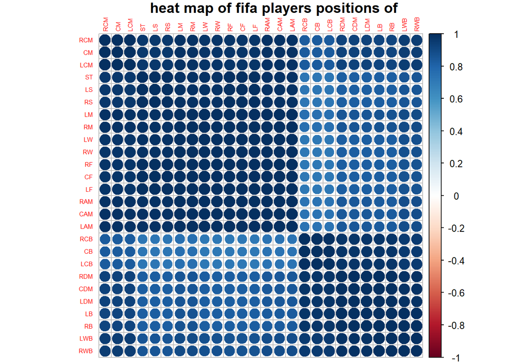

```r
cor_met_3A_pos <- cor(fifa_players_positions[2:27],fifa_players_positions[2:27])
P3A <-corrplot(cor_met_3A_pos,title="heat map of fifa players positions of ",tl.cex = 0.5,order='hclust',mar=c(0,3,1,0))
```

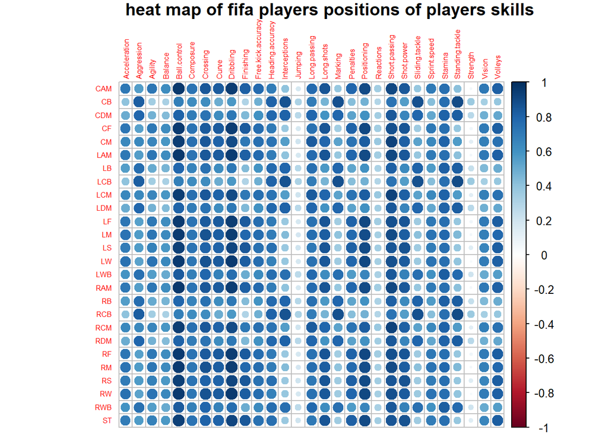

```r
new_table3A <- fifa_players_attribures[2:35]
new_table3A[,12:16] <- NULL

cor_met_3A1_pos <- cor(fifa_players_positions[2:27],
                       new_table3A[1:29])
P3A1 <-corrplot(cor_met_3A1_pos,title="heat map of fifa players positions of players skills",tl.cex = 0.5,mar=c(0,3,1,0))
```

For the first question where we compared the different positions brighter colors represent low correlation, and darker colors represent high correlation. As we can see the 3 position with the brightest colors are RCB,CB and LCB. For the second question about the similarity of the different skills, we can see clearly that Jumping and Strength are very bright so are uncorrelated to other skills.

Q3B

Here we want to compare some indicators to some variables. In order to do so we will take a look at a correlation table a little different than before that plots black and white circles. Black circles are negative correlation, and white circles are positive correlation, and the bigger the circle is the larger the correlation is.

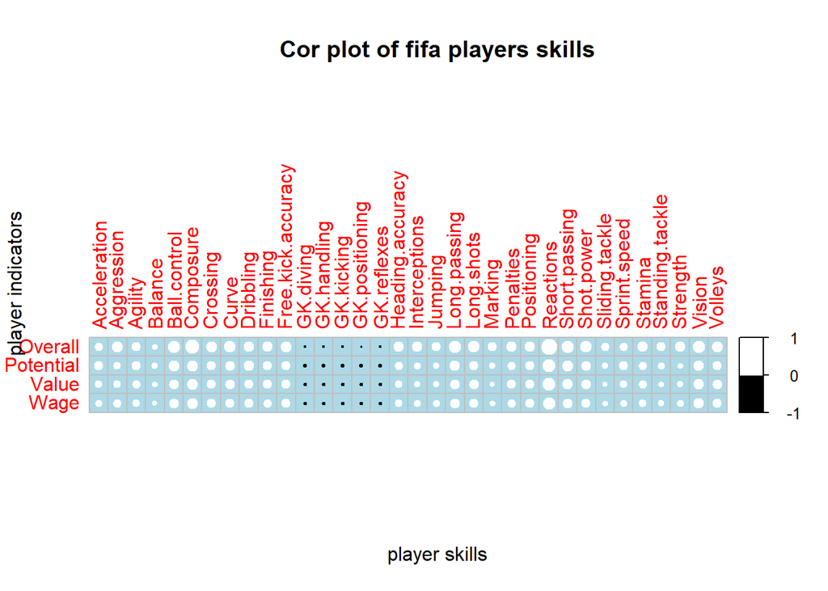

```
## integer(0)
```

```r
new_table_3B <- left_join(fifa_players_attribures, fifa_players_indicators ,by=c("ID"="ID" ,"Overall"="Overall"))
cor_met_3B <- cor(new_table_3B[36:39],new_table_3B[2:35])
corrplot(cor_met_3B, method="circle",tl.cex =1,col=c("black", "white"),
         bg="lightblue")+ theme(axis.text.x = element_text(face = "bold", size = 9, angle = -90, hjust = 0))+title("Cor plot of fifa players skills",xlab="player skills",ylab="player indicators")
```

```r
sum_cor <- apply(cor_met_3B,2,sum)
ave_cor <- sum_cor/4
sort_top_ave <- sort(ave_cor)
top_10_average_cor_skill <-sort_top_ave[34:25]
top_10_table <- data.frame(top_10_average_cor_skill)
top_10_table
```

```
##               top_10_average_cor_skill
## Reactions                       0.6032
## Composure                       0.4604
## Vision                          0.3787
## Short.passing                   0.3783
## Ball.control                    0.3581
## Long.passing                    0.3529
## Shot.power                      0.3207
## Curve                           0.3176
## Long.shots                      0.3124
## Volleys                         0.3028
```

Q3C

Each position we want to arrange by descent order with a for loop, then we want to take 10 the best players from the 26 positions by using the head(10) function on that arranged table, and then take the best goal kipper so we will get an 11 players team.

```r
vec_name <- names(fifa_players_positions)
m = matrix(0,1,30)
new_data3C <- data.frame(m)
names(new_data3C) <- c(vec_name)
for (i in 2:27){
  new_data <-  fifa_players_positions %>%
  arrange(desc(fifa_players_positions[i])) %>%
  head(10)
  new_data <- filter(new_data,new_data[i]==new_data[1,i])
  new_data3C <- rbind(new_data3C,new_data)
}
new_data3C <- new_data3C[2:43,]
GK_filter <- filter(fifa_players_positions,Preferred.Positions=="GK ")
GK_filter <-  GK_filter %>%
  arrange(desc(GK_filter[,29])) %>%
  head(1)
new_data3C <- rbind(new_data3C,GK_filter)
uniq_palyer  <-  new_data3C %>%
                    distinct(ID, .keep_all = TRUE)
top_11_player <- uniq_palyer %>%
  arrange(desc(uniq_palyer[,29])) %>%
  head(11)
top_11_player <- left_join(top_11_player, fifa[1:2] ,by=c("ID"="ID"))
top_11_player <-select(top_11_player,Name,Overall)
top_11_player
```

```
##                 Name Overall
## 1  Cristiano Ronaldo      94
## 2           L. Messi      93
## 3           M. Neuer      92
## 4       Sergio Ramos      90
## 5           T. Kroos      90
## 6           A. Vidal      87
## 7            Marcelo      87
## 8        Alex Sandro      86
## 9           D. Alaba      86
## 10     R. Nainggolan      86
## 11       Azpilicueta      85
```

```r
top_6_player <- filter(fifa,Name =="Cristiano Ronaldo"|Name=="L. Messi"|Name=="M. Neuer"|Name=="A. Vidal"|Name=="Sergio Ramos"|Name=="T. Kroos")
top_6_player_10_skills <- select(top_6_player,Name,names(top_10_average_cor_skill))
radarDF <- gather(top_6_player_10_skills, key=Label, value=Score, -Name) %>%
  spread(key=Name, value=Score)

chartJSRadar(scores = radarDF, maxScale = 100, showToolTipLabel = TRUE)
```

[interactive chart not shown]

The top 11 player table got us the best 11 players. The top 6 player plot shows us for 6 players from our team there abilities. Each color is for a different player and we check there abilities over 10 skills, as it should be in a radar chart.

Q3D

The best way to show the change in abilities as players get older is by multiple table one for each skill.

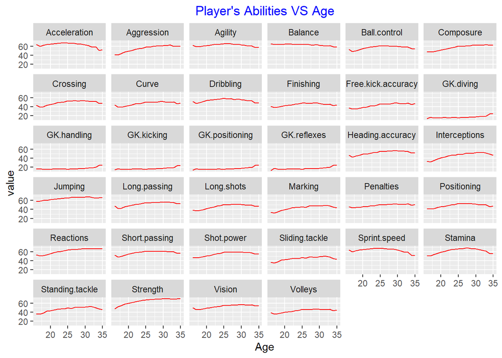

```r
new_table3D <-left_join(fifa_players_attribures[1:35],fifa[1:3],by=c("ID"="ID" ))
filter_3D <- filter(new_table3D,Age <= 35)
filter_3D$Name<- NULL
filter_3D$ID<- NULL
group3D <- aggregate(.~ Age, data= filter_3D, FUN = mean)
skills_per_age <- gather(group3D,skills, value, -Age)
ggplot(data=skills_per_age, aes(x=Age, y=value, group=skills)) +
  geom_line(col="red")+
  ggtitle("Player's Abilities VS Age") +
  theme(plot.title = element_text(hjust = 0.5,color="blue"))+
  facet_wrap(~skills)  +
  theme(legend.position="none")
```

The skills getting a peak for younger players are: acceleration, Agility, sprint speed.

The skills getting a peak for older players are: GK.diving,GK.handling,GK.kicking,GK.positioning,GK.reflexes,Free kick accuracy,Aggression,strength.

It makes a lot of sense that all GK skills are improved for older GK because it is possible that GK tend to play for more years than an average player.

Q3E

All we need to do for this question is to make a new table, create a regression between the wanted variables, and arrange by descent order the residuals. The top 10 residuals are the wanted players.

```r
new_table3E <- select(fifa,Name,Overall,Age,Wage)
reg_Ov_Ag_Wa <- lm(Overall ~ Age+Wage, data = new_table3E)
sum_red_3E <- summary(reg_Ov_Ag_Wa)
resid <- resid(sum_red_3E) #List of residuals
new_table3E$resid <- resid
new_table3E1 <- new_table3E %>%
  arrange(desc(resid)) %>%
  head(10)
new_table3E1
```

```
##              Name Overall Age  Wage resid
## 1           Oscar      83  25     0 18.67
## 2      K. Mbapp\303©      83  18 31000 17.72
## 3    Adrien Silva      83  28     0 16.94
## 4     Sergio Rico      82  23 16000 16.25
## 5            Fred      80  24  1000 16.08
## 6   G. Donnarumma      82  18 35000 16.08
## 7        Grimaldo      80  21 12000 16.05
## 8       A. Witsel      82  28     0 15.94
## 9  Danilo Pereira      83  25 18000 15.78
## 10     K. Dolberg      78  19 10000 15.52
```

The players in the table are the most underrated players.

## Q4. Fix Problematic Plots (10 pt)

The previous data-analyst of the club was fired for producing poor plots. See below two bar plots that he made including their code.

1. Describe in your own words what did your predecessor try to show in each of the two plots.
2. Find *at least* three *different* problematic issues with his plots, and explain them.
3. Fix the problematic issues above in the code below to generate new, improved plots.  
   You will get an additional *bonus* point for finding any additional problem and fixing it.  
   (identifying the *same* problem in the two plots counts as *one* problem).

```r
# A measure of category's diversity
DIV <- function(category_vec){
  t <- table(category_vec)
  p <- t/sum(t)
  return(sum(p^2))
}

cleaned_data <- fifa_players %>% select(Nationality,Club) %>% na.omit()

number_of_nationality_in_club <- cleaned_data %>% group_by(Club, Nationality) %>% summarise(count = n()) %>% group_by(Club) %>% summarise(N_nation=n()) %>% arrange(desc(N_nation)) %>% mutate(Club = factor(Club, level=unique(Club)))
```

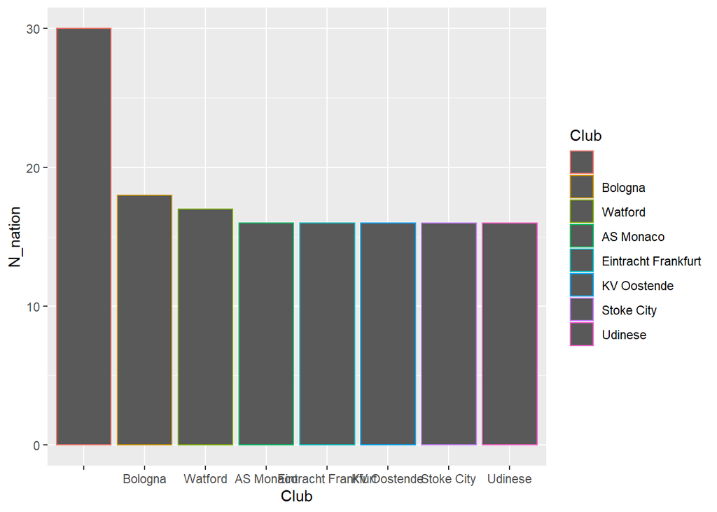

```r
DIV_in_club <- cleaned_data %>% group_by(Club) %>% summarise(DIV = DIV(Nationality))%>% arrange(DIV)%>% mutate(Club = factor(Club,level=unique(Club)))  # arrange(desc(DIV)) %>%

# Plot number of different nationalities in each club
g <- ggplot(data = number_of_nationality_in_club %>% head(8), aes(x = Club, y = N_nation,color = Club))
g + geom_bar(stat="identity")
```

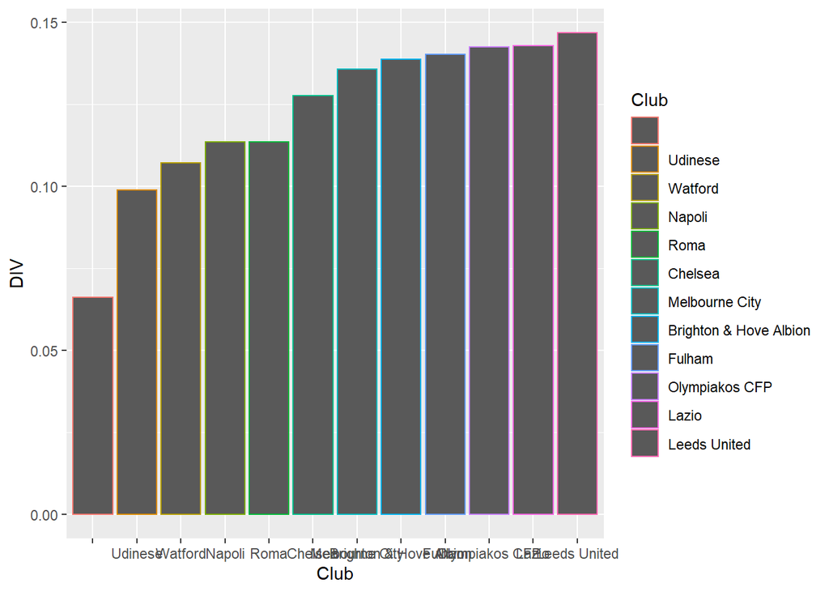

```r
# Plot DIV (diversity?) of different nationalities in each club
g <- ggplot(data = DIV_in_club %>% head(12),aes(x = Club,y = DIV, color = Club))
g <- g + geom_bar(stat="identity")
g
```

Q4B He did not clean the data, he still has a ‘NA’ column. The color of bars is the same and only the line is different. The text under the plot is unclear. The plot dosen’t have a title. The y axis dosen’t have an informtiv label.

Q4C

```r
cleaned_data <- fifa_players %>% select(Nationality,Club) %>% na.omit()

number_of_nationality_in_club <- cleaned_data%>%filter(Club!="") %>% group_by(Club, Nationality) %>% summarise(count = n()) %>% group_by(Club) %>% summarise(N_nation=n())  %>% arrange(desc(N_nation))%>% mutate(Club = factor(Club, level=unique(Club)))
```

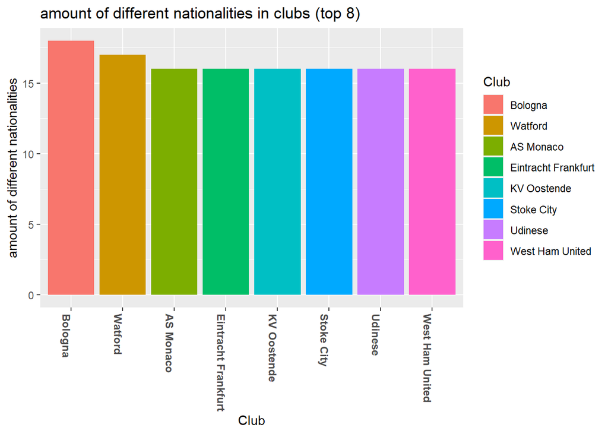

```r
DIV_in_club <- cleaned_data %>%filter(Club!="")%>% group_by(Club) %>% summarise(DIV = DIV(Nationality)) %>%filter(Club!="")%>% arrange(DIV)%>%mutate(Club = factor(Club,level=unique(Club)))  # arrange(desc(DIV)) %>%

# Plot number of different nationalities in each club
g <- ggplot(data = number_of_nationality_in_club %>% head(8), aes(x = Club, y = N_nation,fill = Club))
g + geom_bar(stat="identity")+ theme(axis.text.x = element_text(face = "bold", size = 9, angle = -90, hjust = 0)) + ylab('amount of different nationalities') +
labs(title="amount of different nationalities in clubs (top 8)")
```

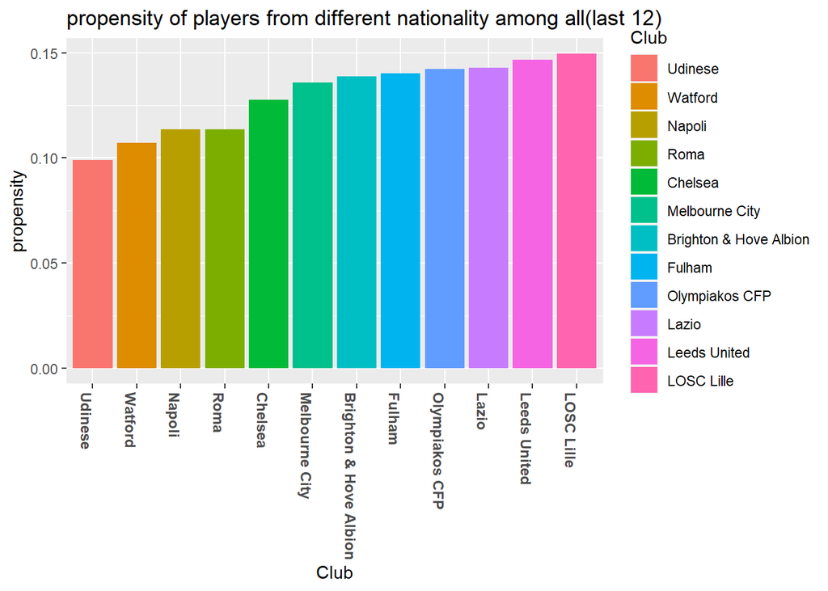

```r
# Plot DIV (diversity?) of different nationalities in each club
g <- ggplot(data = DIV_in_club %>% head(12),aes(x = Club,y = DIV, fill = Club))
g <- g + geom_bar(stat="identity") + theme(axis.text.x = element_text(face = "bold", size = 9, angle = -90, hjust = 0)) + ylab('propensity') +
labs(title="propensity of players from different nationality among all(last 12)")
g
```